# my_exp_report

Ranma Yoshida(2412C22)

## 1. 目的 (Introduction)

本研究では、作業記憶（ワーキングメモリ）における認知負荷が情報処理パフォーマンス（反応時間および正答率）に与える影響について検討する。

ワーキングメモリとは、情報を短時間保持しつつ同時に処理を行う心理的機構であり、意思決定や問題解決などの高次認知機能の中核をなす (Baddeley, 1992)。ワーキングメモリの容量制限や負荷の影響を測定する代表的な課題としてN-Back課題が存在する (Kirchner, 1958)。N-Back課題では、提示された刺激が「N個前」の刺激と一致しているかどうかを判断する。負荷が少ない1-Back条件に比べ、より過去の情報更新と保持を要求される2-Back条件（認知負荷が高い条件）では、処理資源の枯渇に伴いパフォーマンスが低下することが報告されている (Jaeggi et al., 2010)。

本実験では、1-Back条件と2-Back条件を比較し、認知負荷が増大することによるパフォーマンスへの影響を検証した。本実験の仮説は以下の2点とした。 1. **仮説1：** 2-Back条件（高負荷）は1-Back条件（低負荷）よりも正答反応時間が長くなる。 2. **仮説2：** 2-Back条件（高負荷）は1-Back条件（低負荷）よりも正答率が低下する。

## 2. 方法 (Method)

### 装置と材料

オンライン実験プラットフォーム（jsPsych v7.3）を使用してWebベースの実験プログラムを構築した。刺激には画面中央に提示される英大文字（A, B, C, D, E, F, G, H）を使用し、黒背景上に白文字でランダムに表示された。刺激提示時間は500ms、刺激提示間隔（ISI）は1500msであった。データ収集および実験のホスティングには GitHub Pages を利用した。

### 手続き

参加者は自身のPCまたはスマートフォンのブラウザから実験アクセス用URLに接続した。 実験は試行練習ののち、以下の2つの条件（ブロック）で構成された。

1. **1-Back条件:** 直前に提示された文字と同じ文字が出現した際に、キーボードの「Spaceキー」（スマホの場合は「MATCH」ボタン）を押すよう求められた。
2. **2-Back条件:** 2つ前に提示された文字と同じ文字が出現した際に、同様にレスポンスを行うよう求められた。

条件の順序は参加者間でカウンターバランスをとった。各条件につき30試行（ターゲット刺激10試行、非ターゲット刺激20試行）を実施し、正答率（%）および正しい試行の反応時間（ms）を記録した。

## 3. 結果 (Results)

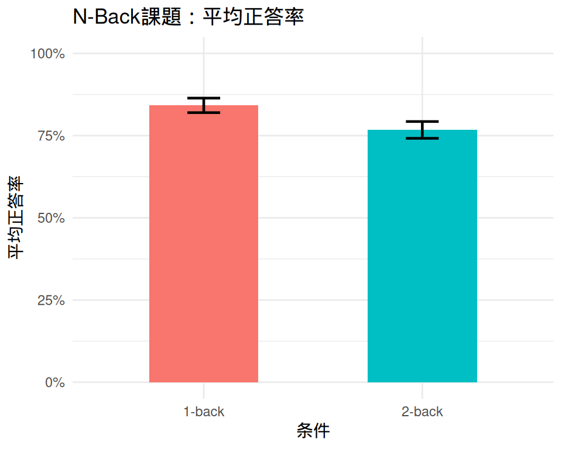

[output not shown]

## 4. 考察

一方で2-Back条件では、以下の複合的な認知プロセスを並行して行う必要がある。 １．新しい刺激の入力受容 ２．2つ前に表示された刺激との比較判定 ３．保持している記憶項目の更新（古い刺激の破棄と新しい刺激の順次シフト） 4.無関連な刺激に対する不要な反応の抑制